# Multidimensional Scaling

Jyotishka Datta

April 27, 2018

# 1 Multidimensional Scaling

Most of the following material is from tutorials on MDS available online, in particular, an excellent set of notes from ETH.

## 1.1 Basic Question:

How to represent any data in two dimensions?

1. Projection (onto a lower dimensional plane)
2. Squeeze data onto a table: close points stay close.
- Both ideas yield sensible visualization - but show a different aspect of the data.

## 1.2 Which idea is better?

This is a nice analogy for visualization. Each method uncovers only partial truth. We should bear that in mind.

[figure not shown]

## 1.3 Idea of MDS

- Represent high-dimensional point cloud in few (usually 2) dimensions keeping distances between points similar.
- Useful tool in visualizing any big data-set, specially for clustering purposes.
- Is a popular exploratory tool. Used before any inferential procedure.

## 1.4 Goal of MDS

- Given pairwise dissimilarities, reconstruct a map that preserves distances.
- From any dissimilarity (no need to be a metric)
- Reconstructed map has coordinates $\mathbf{x}_i = (x_{i1}, x_{i2})$ and the natural distance $\Vert x_i - x_j \Vert^2$.
- MDS is a family of different algorithms, each designed to arrive at optimal low-dimensional configuration (p = 2 or 3)
- Includes: Classical MDS, Metric MDS and Non-metric MDS.

# 2 Examples first - Classical MDS

- Problem: Given Euclidean Distance between points, recover the position of the points.
- Example: Road distance between 21 european cities.

```r
library(datasets); class(eurodist)
```

```
## [1] "dist"
```

```
                Athens Barcelona Brussels Calais Cherbourg Cologne
Barcelona         3313
Brussels          2963      1318
Calais            3175      1326      204
Cherbourg         3339      1294      583    460
Cologne           2762      1498      206    409       785
```

## 2.1 First Try MDS

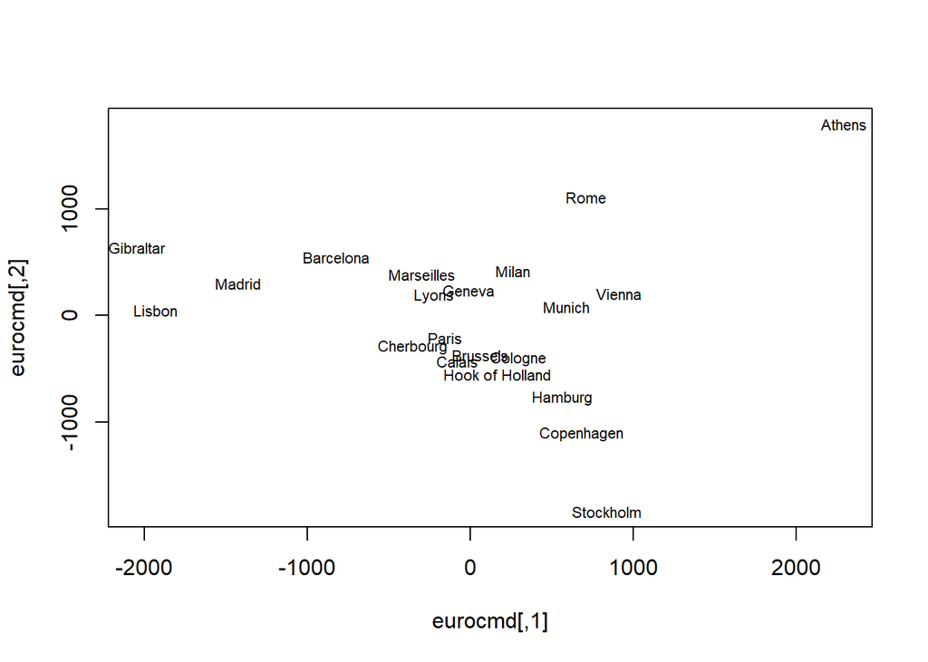

```r
eurocmd <- cmdscale(eurodist)
plot(eurocmd, type = "n")
text(eurocmd, rownames(eurocmd), cex = 0.7)
```

## 2.2 Do we recover?

[figure not shown]

- Can identify points up to shift, reflection and rotation.

## 2.3 Flip Axes

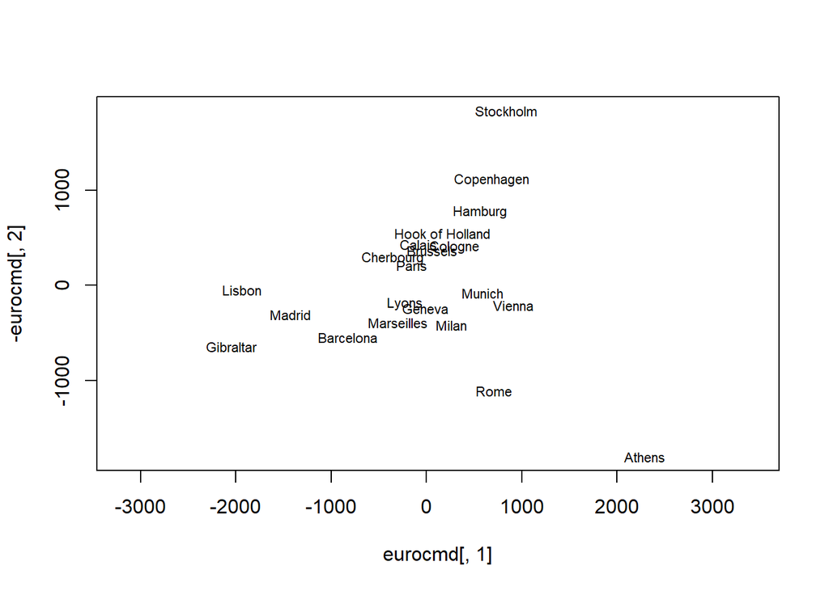

```r
plot(eurocmd[,1], -eurocmd[,2], type = "n", asp = 1)
text(eurocmd[,1], -eurocmd[,2], rownames(eurocmd), cex = 0.7)
```

- Can identify points up to shift, reflection and rotation.

## 2.4 Another Example

- Air pollution in US Cities

```r
data("USairpollution", package = "HSAUR2")
summary(USairpollution)
```

```
##       SO2              temp            manu            popul
##  Min.   :  8.00   Min.   :43.50   Min.   :  35.0   Min.   :  71.0
##  1st Qu.: 13.00   1st Qu.:50.60   1st Qu.: 181.0   1st Qu.: 299.0
##  Median : 26.00   Median :54.60   Median : 347.0   Median : 515.0
##  Mean   : 30.05   Mean   :55.76   Mean   : 463.1   Mean   : 608.6
##  3rd Qu.: 35.00   3rd Qu.:59.30   3rd Qu.: 462.0   3rd Qu.: 717.0
##  Max.   :110.00   Max.   :75.50   Max.   :3344.0   Max.   :3369.0
##       wind            precip         predays
##  Min.   : 6.000   Min.   : 7.05   Min.   : 36.0
##  1st Qu.: 8.700   1st Qu.:30.96   1st Qu.:103.0
##  Median : 9.300   Median :38.74   Median :115.0
##  Mean   : 9.444   Mean   :36.77   Mean   :113.9
##  3rd Qu.:10.600   3rd Qu.:43.11   3rd Qu.:128.0
##  Max.   :12.700   Max.   :59.80   Max.   :166.0
```

```r
dat <- USairpollution # less typing
```

- Some variables have larger range - need to standardise.

## 2.5 Try MDS at 2-D

```r
xs <- apply(dat, 2, function(x) (x - min(x))/(diff(range(x))))
poldist <- dist(xs)
pol.mds <- cmdscale(poldist, k = 2, eig = TRUE)
x <- pol.mds$points
pol.mds
```

```
## $points
##                        [,1]         [,2]
## Albany          0.140558172 -0.046859954
## Albuquerque    -0.364824787 -0.636602091
## Atlanta        -0.155922591  0.244511276
## Baltimore       0.153189990  0.067519907
## Buffalo         0.256244063  0.003022604
## Charleston     -0.128730958  0.215783429
## Chicago         1.197000315  0.009638168
## Cincinnati     -0.084166097  0.106828800
## Cleveland       0.531787447  0.056305378
## Columbus        0.025412911  0.033574934
## Dallas         -0.258008194 -0.062640448
## Denver         -0.110682033 -0.510378502
## Des Moines     -0.007603614 -0.244344703
## Detroit         0.341537781 -0.105917971
## Hartford        0.206766531  0.105259858
## Houston        -0.188167760  0.243707765
## Indianapolis    0.069589745  0.010565926
## Jacksonville   -0.349520267  0.412490203
## Kansas City    -0.106424371 -0.085118726
## Little Rock    -0.355970056  0.194004542
## Louisville     -0.046780470  0.144850917
## Memphis        -0.249259311  0.208737990
## Miami          -0.449823739  0.604996816
## Milwaukee       0.217298744 -0.249612250
## Minneapolis     0.326439578 -0.242858309
## Nashville      -0.215002650  0.211835269
## New Orleans    -0.410715158  0.438263300
## Norfolk        -0.066285208  0.149134571
## Omaha          -0.063335982 -0.241936316
## Philadelphia    0.521031706  0.081089446
## Phoenix        -0.695773353 -0.527859295
## Pittsburgh      0.314965899  0.074640031
## Providence      0.466505620  0.110503750
## Richmond       -0.191967563  0.140461889
## Salt Lake City -0.111111665 -0.461383196
## San Francisco  -0.253430076 -0.401897024
## Seattle         0.170829143  0.147411289
## St. Louis       0.162208664 -0.016576959
```

[output cut: 8 more lines]

```
## [16]  6.686099e-17  5.684599e-17  5.034791e-17  4.025565e-17  3.312471e-17
## [21]  2.974204e-17  1.555983e-17  1.132251e-17  3.668800e-18 -5.206488e-18
## [26] -8.948794e-18 -9.519928e-18 -1.506805e-17 -1.853275e-17 -2.314710e-17
## [31] -2.858271e-17 -3.093804e-17 -3.151435e-17 -3.396470e-17 -7.209856e-17
## [36] -7.714641e-17 -1.524915e-16 -2.390840e-16 -2.833661e-16 -3.238640e-16
## [41] -1.263609e-15
##
## $x
## NULL
##
## $ac
## [1] 0
##
## $GOF
## [1] 0.6050889 0.6050889
```

## 2.6 Plot the 2-D map

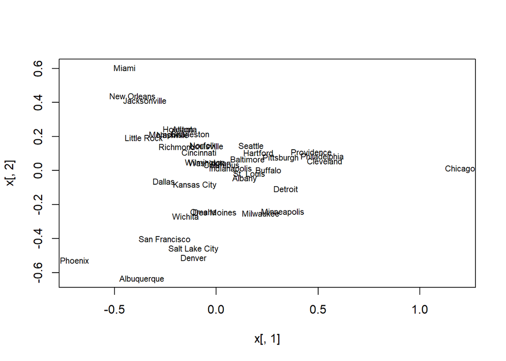

```r
plot(x[,1], x[,2], type = "n")
text(x[,1], x[,2], labels = rownames(x), cex = 0.7)
```

**Note that we can use the `ggrepel` package to reduce the amount of text overlap**

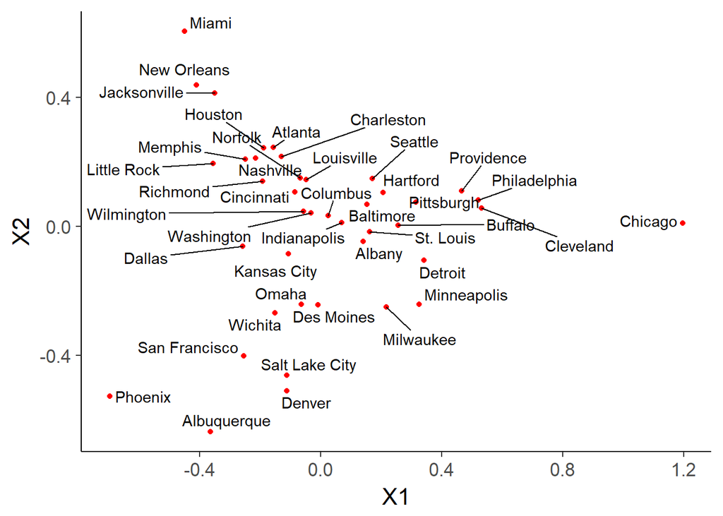

```r
pol.data <- data.frame(x)

set.seed(42)
ggplot(pol.data) +
  geom_point(aes(X1,X2), color = 'red') +
  geom_text_repel(aes(X1,X2,
                      label = rownames(pol.data))) +
  theme_classic(base_size = 16)
```

## 2.7 Star plot

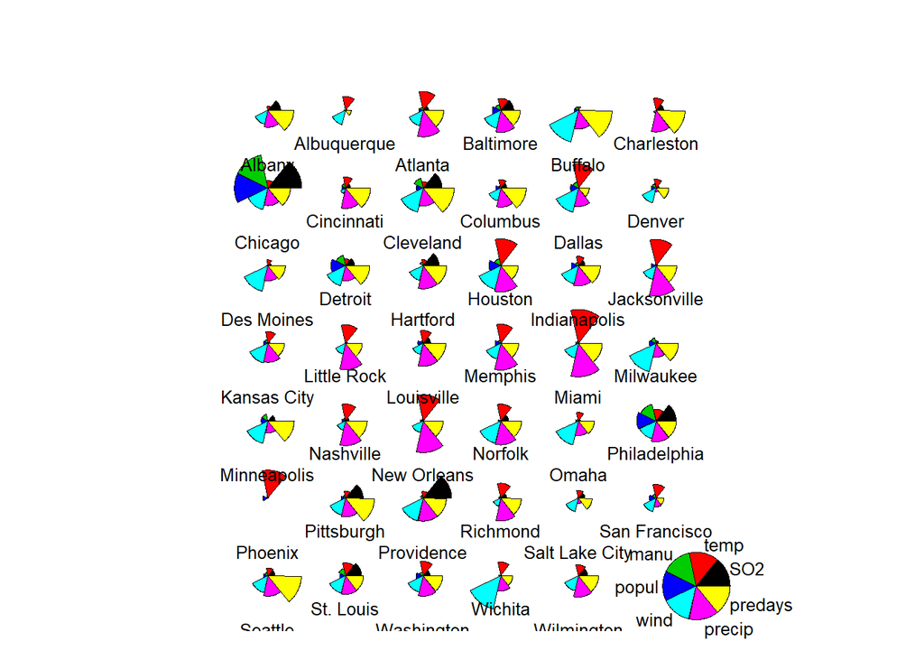

```r
stars(xs, draw.segments = TRUE, key.loc = c(15,2))
```

- Jacksonville and New Orleans have similar profile.

# 3 Thoery of MDS

- Classical MDS: Euclidean distance between $n$ objects in $p$ dimensions.
- Output: Position of points upto rotation, reflection, shift.
- Two steps:
1. Compute inner product matrix $B = X X^T$ from distances.
2. Compute positions from $B$.

## 3.1 Distance

- Distance, dissimilarity and similarity (or proximity) are defined for any pair of objects in any space.
- In mathematics, a distance function (that gives a distance between two objects) is also called metric, satisfying:

$$d(x,y) \ge 0 \\
d(x,y) = 0 \text{ iff } x = y \\
d(x,y) = d(y,x) \\
d(x,z) \le d(x,y) + d(y,z)$$

## 3.2 Examples

1. Euclidean Distance:
   $$d_{i,j} = \sqrt{(x_{i1}-x_{j1})^2 + \ldots + (x_{ip}- x_{jp})^2}$$
2. Manhattan distance:
   $$d_{i,j} = \lvert x_{i1} -x_{j1} \rvert + \ldots \lvert x_{ip}-x_{jp} \rvert$$
3. Maximum distance:

$$d_{i,j} = \sum_{k=1}^{p} |x_{ik} - x_{jk}|_{\infty} = max_{k=1}^{p} |x_{ik} - x_{jk} |$$

## 3.3 Intuition for Minkowski distance

**Minkowski distance**:

$$d_{i,j} = \{ \sum_{k=1}^{p} \sum_{k=1}^{p} |x_{ik} - x_{jk}|^q \}^{1/q}$$

1. Points on the line have equal distance from the center.
2. Different distances for different index $q$:

**Shape of different $\ell_p$ norms:**

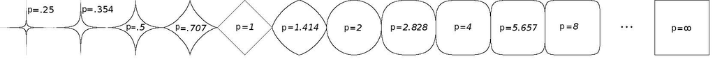

## 3.4 Distance metrics in practice

1. Euclidean Distance: By far most common Our intuitive notion of distanc.
2. Manhattan Distance: Sometimes seen
3. Rest: Very rare

## 3.5 To scale or not to scale

4 persons data on age and height.

| Person | Age [years] | Height [cm] |
| --- | --- | --- |
| A | 35 | 190 |
| B | 40 | 190 |
| C | 35 | 160 |
| D | 40 | 160 |

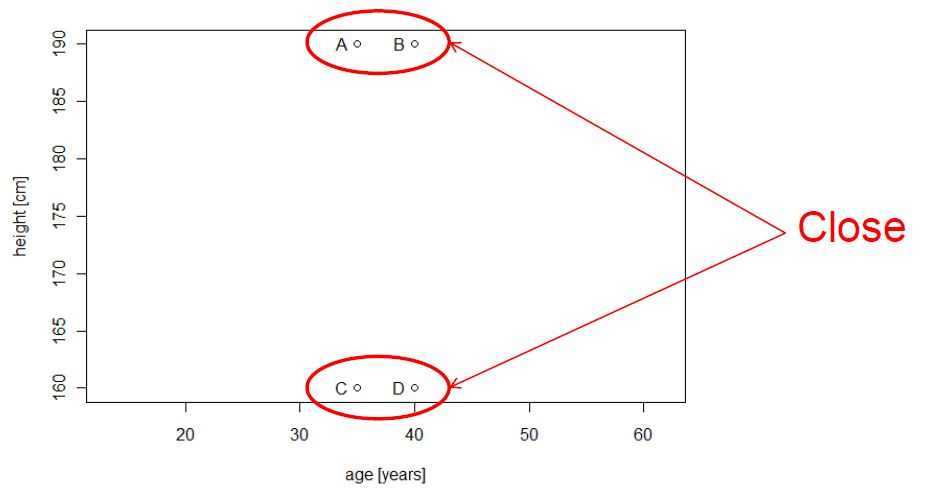

| Person | Age [years] | Height [ft] |
| --- | --- | --- |
| A | 35 | 6.232 |
| B | 40 | 6.232 |
| C | 35 | 5.248 |
| D | 40 | 5.248 |

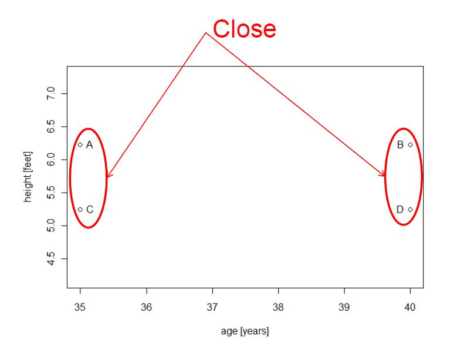

Convert cm to feet: different subgroups emerge.

| Person | Age [years] | Height [cm] |
| --- | --- | --- |
| A | -0.87 | 0.87 |
| B | 0.87 | 0.87 |
| C | -0.87 | -0.87 |
| D | 0.87 | -0.87 |

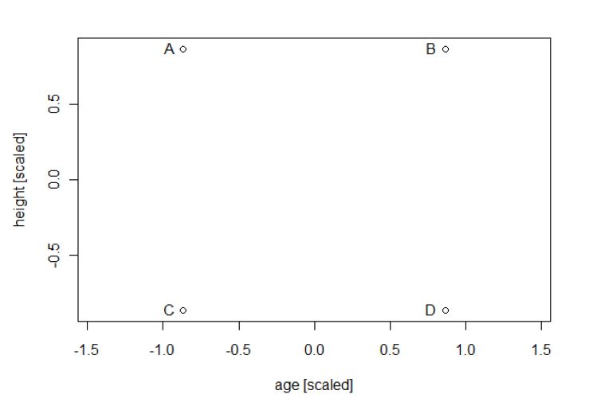

Now all data-points are scaled : no subgroups.

## 3.6 Context is important

Which of the two representations make sense?

| Object | X1 | X2 |
| --- | --- | --- |
| A | 13.3 | 38 |
| B | 12.4 | 45.4 |
| C | -122.7 | 45.6 |
| D | -122.4 | 37.7 |

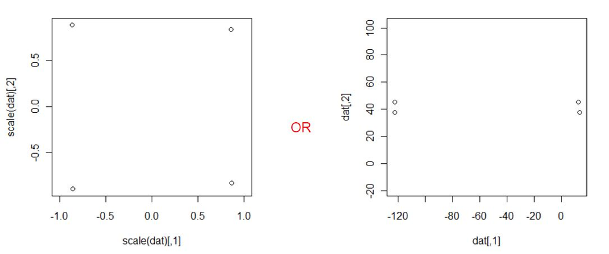

**Without knowing what these objects are, it is difficult to make a choice**.

For example, here the 4 objects are 4 cities and $X$, $Y$ are the geo-codes (longitude, latitude) - so scaling them does not make sense.

In other words, you need knowledge of the context. Scaling is not a good idea always.

| Object | Longitude | Latitude |
| --- | --- | --- |
| Palermo | 13.3 | 38 |
| Venice | 12.4 | 45.4 |
| Portland | -122.7 | 45.6 |
| San Francisco | -122.4 | 37.7 |

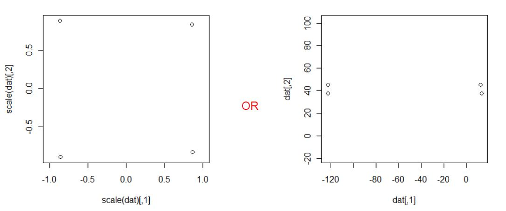

## 3.7 Thoery of MDS

- Given a dissimilarity matrix $D = (d_{ij})$, MDS seeks to find $x_1, \ldots, x_n \in \mathbb{R}^p$, such that:
  $$d_{ij} \approx \Vert x_i - x_j \Vert^2 \text{ as close as possible}$$
- Oftentimes, for some large $p$, there exists a configuration $x_1, \ldots, x_n$ with exact distance match $d_{ij} = \Vert x_i - x_j \Vert^2$.
- In such a case $d$ is called a Euclidean distance.
- There are, however, cases where the dissimilarity is distance, but there exists no configuration in any $p$ with perfect match.
- Such a distance is called non-Euclidean distance.

## 3.8 Classical MDS: Thoery (continued)

- Suppose for now we have Euclidean distance matrix $D = (d_{ij})$
- We want to find $(x_1, \ldots, x_n)$ such that $d_{ij} = dist(x_i,x_j)$.
- Not unique solution: $x^* = x + c$.
- Assume the observations are centered.

## 3.9 Thoery - Step 1

- Find inner product matrix $B = X X^T$ instead of $X$.
- Conenct to distance: $d_{ij}^2 = b_{ii}+b_{jj}-2b_{ij}$.
- Center points to avoid shift invariance.
- Invert relationship:
  $$b_{ij} = -1/2(d_{ij}^2 - d_{i.}^2 - d_{.j}^2 + d_{..}^2)$$
- “Doubly centered” distance.

## 3.10 Theory - Step 2

- Since $B = X X^T$, we need the square-root of $B$.
- $B$ is symmetric and positive definite.
- Can be diagonalised: $B = V \Lambda V^T$.
- $\Lambda$ is diagonal matrix with eigenvalues $\lambda_1 > \lambda_2 > \cdots > \lambda_n$
- Some eignevalues are zero, drop them. $B = V_1 \Lambda_1 V_1^T$.
- Take “square-root” $X = V_1 \Lambda_1^{1/2}$.

## 3.11 Classical MDS

- Want a 2-D plot.
- Keep only largest 2 eignevectors and eignevalues.
- The resulting $X$ will be the low-dimensional representation we were looking for.
- Same for 3-D.

## 3.12 Classical MDS: Low-dim representation

- Goodness of fit (GOF) if we reduce to m dimensions:
  $$\text{GOF}_{m} = \frac{\sum_{i = 1}^{m} \lambda_i}{\sum_{i = 1}^{n} \lambda_i}$$
- We can choose $m$ dimensional representation if $\text{GOF}_{m} \ge 0.8$.

## 3.13 Classical MDS: Pros and Cons

Pros:

- Optimal for euclidean input data
- Still optimal, if $B$ has non-negative eigenvalues (pos. semidefinite)
- Very fast

Cons: - No guarantees if $B$ has negative eigenvalues.

However, in practice, it is still used then. New measures for Goodness of fit:
$$\text{GOF}_{m} = \frac{\sum_{i = 1}^{m} \vert \lambda_i \vert}{\sum_{i = 1}^{n} \vert \lambda_i \vert} \; \text{or} \; \text{GOF}_{m} = \frac{\sum_{i = 1}^{m} \Vert \lambda_i \Vert_{\infty}}{\sum_{i = 1}^{n} \Vert \lambda_i \Vert_{\infty}}$$
- These are used in the R function `cmdscale`.

## 3.14 Non-metric MDS: Idea

- Sometimes, there is no strict metric on original point
- Example: how well do you like something? (1 - not at all, 10 - very much)

| Subject | Teacher-1 | Teacher-2 | Teacher-3 |
| --- | --- | --- | --- |
| S1 | 1 | 5 | 10 |
| s2 | 2 | 6 | 9 |
| S3 | 1 | 7 | 8 |

- Teacher 1 < Teacher 2 < Teacher 3

## 3.15 Non-metric MDS

- Absolute values are not that meaningful
- Ranking is important
- Non-metric MDS finds a low-dimensional representation, which respects the ranking of distances.

## 3.16 Non-metric MDS : Theory

- $\delta_{ij}$ is the true dissimilarity: $d_{ij}$ is the distance of representation.
- Minimize Stress:
  $$S = \frac{\sum_{i <j} (\theta(\delta_{ij}) - d_{ij})^2}{\sum_{i <j} d_{ij}^2}, \; \theta \text{ is an increasing function}.$$
- Optimize over “both” positions of points and $\theta$.
- $\hat{d_{ij}} = \theta(\delta_{ij})$ is called “disparity”.
- Solved numerically (isotonic regression); Classical MDS as starting value;
- very time consuming

## 3.17 Example for Intuition

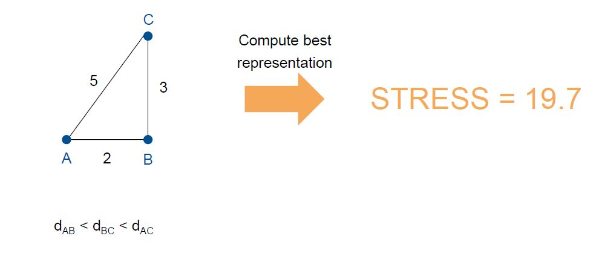

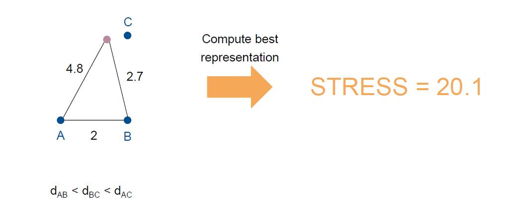

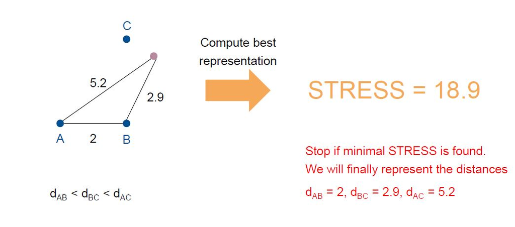

## 3.18 Non-metric MDS: Pros and Cons

- Fulfills a clear objective without many assumptions (minimize STRESS)
- Results don’t change with rescaling or monotonic variable transformation
- Works even if you only have rank information
- Slow in large problems
- Usually only local (not global) optimum found
- Only gets ranks of distances right

# 4 Random Forest and MDS

- In absence of a distance measure, we can use random forest to get a proximity measure.
- Proximity measure: The $(i,j)$ element of the proximity matrix produced by `randomForest` is the fraction of trees in which elements $i$ and $j$ fall in the same terminal node.
- The intuition is that **similar** observations should be in the same terminal nodes more often than dissimilar ones.
- We can use the proximity measure to identify structure.

```r
library(randomForest)
ind <- sample(2,nrow(iris),replace=TRUE,prob=c(0.7,0.3))
trainData <- iris[ind==1,]
testData <- iris[ind==2,]
iris_rf <- randomForest(Species~.,data=trainData,ntree=100,proximity=TRUE)
table(predict(iris_rf),trainData$Species)
```

```
##
##              setosa versicolor virginica
##   setosa         34          0         0
##   versicolor      0         37         2
##   virginica       0          2        36
```

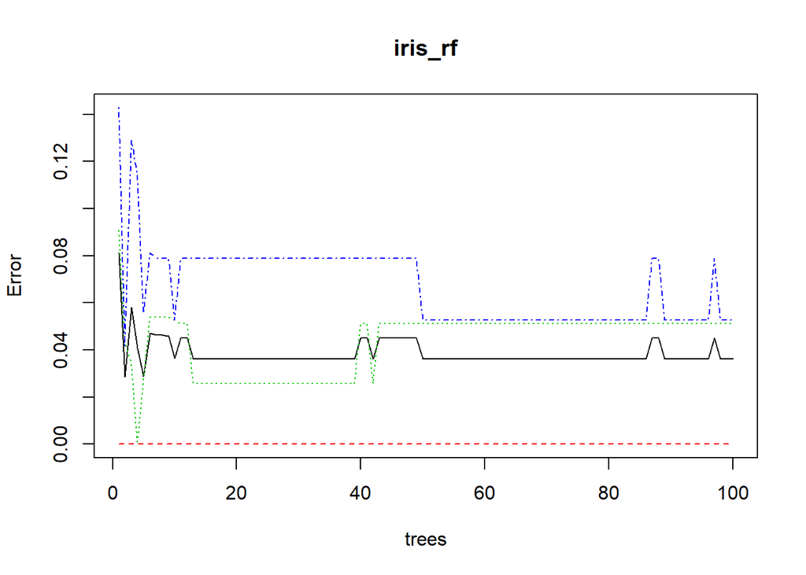

```r
plot(iris_rf)
```

## 4.1 Variable Importance

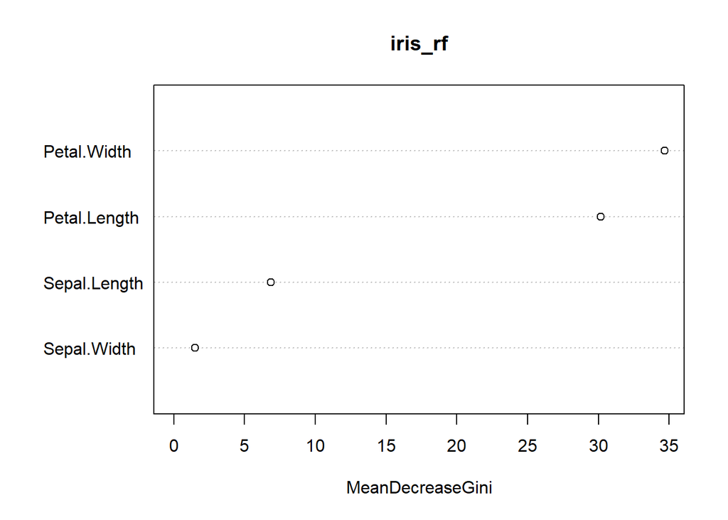

```r
varImpPlot(iris_rf)
```

## 4.2 Prediction on new data

```r
irisPred<-predict(iris_rf,newdata=testData)
table(irisPred, testData$Species)
```

```
##
## irisPred     setosa versicolor virginica
##   setosa         16          0         0
##   versicolor      0         10         1
##   virginica       0          1        11
```

## 4.3 MDS on the full Iris Data

```r
set.seed(71)
iris.rf <- randomForest(Species ~ ., data=iris, importance=TRUE,
                        proximity=TRUE)
## Do MDS on 1 - proximity:
iris.mds <- cmdscale(1 - iris.rf$proximity, eig=TRUE)
## Look at variable importance:
round(importance(iris.rf), 2)
```

```
##              setosa versicolor virginica MeanDecreaseAccuracy
## Sepal.Length   6.04       7.85      7.93                11.51
## Sepal.Width    4.40       1.03      5.44                 5.40
## Petal.Length  21.76      31.33     29.64                32.94
## Petal.Width   22.84      32.67     31.68                34.50
##              MeanDecreaseGini
## Sepal.Length             8.77
## Sepal.Width              2.19
## Petal.Length            42.54
## Petal.Width             45.77
```

## 4.4 Plot the variables

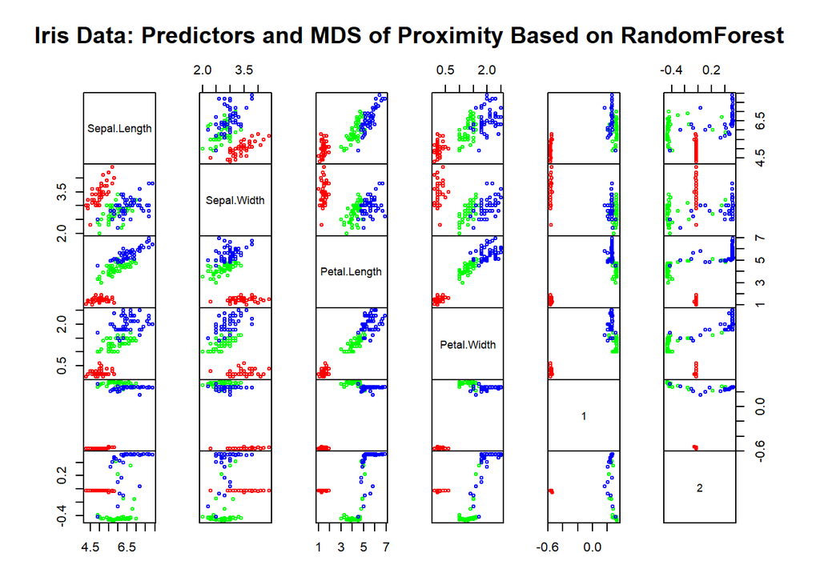

```r
op <- par(pty="s")
pairs(cbind(iris[,1:4], unlist(iris.mds$points)), cex=0.6, gap=0,
      col=c("red", "green", "blue")[as.numeric(iris$Species)],
      main="Iris Data: Predictors and MDS of Proximity Based on RandomForest")
```

```r
par(op)
```

# 5 Voting Data

- Look at the voting data.
- Are Democrats close to each other, republicans?

```r
data("voting", package = "HSAUR")
require("MASS")
head(voting[,1:4], n = 4)
```

```
##             Hunt(R) Sandman(R) Howard(D) Thompson(D)
## Hunt(R)           0          8        15          15
## Sandman(R)        8          0        17          12
## Howard(D)        15         17         0           9
## Thompson(D)      15         12         9           0
```

- For metric MDS, use function `cmdscale`.

```r
voting.mds <- cmdscale(voting, eig=TRUE)
names(voting.mds)
```

```
## [1] "points" "eig"    "x"      "ac"     "GOF"
```

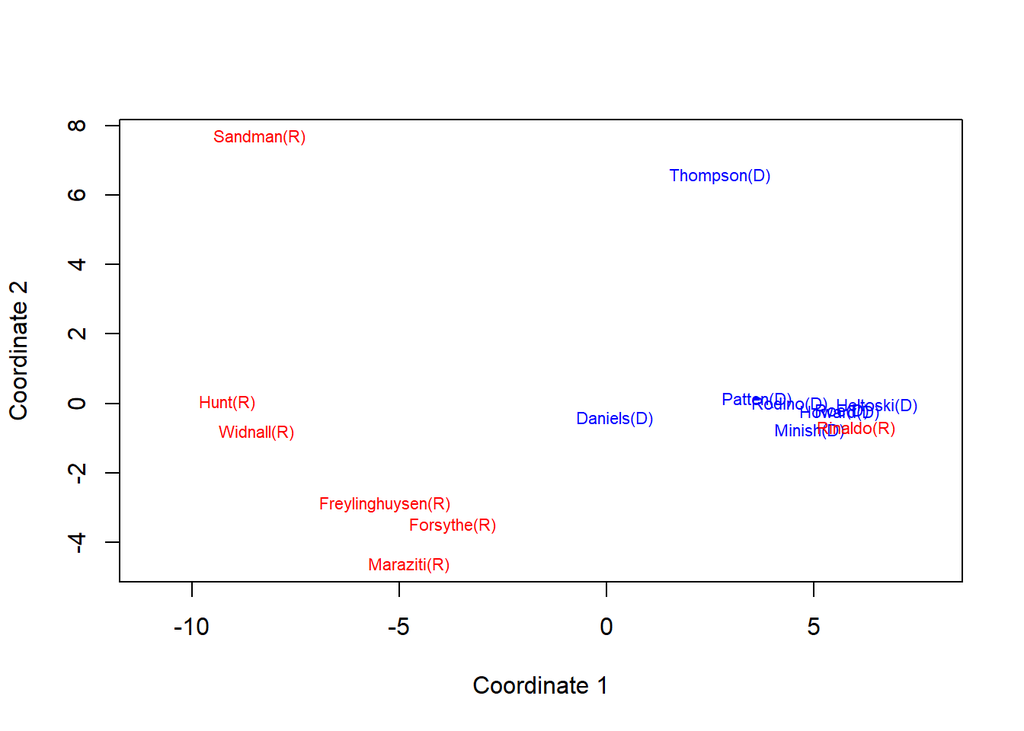

```r
demind <- grep("(D)",colnames(voting))
col <- rep("red",15)
col[demind] <- "blue"

plot(voting.mds$points[,1], voting.mds$points[,2],
     type = "n", xlab = "Coordinate 1", ylab = "Coordinate 2",
     xlim = range(voting.mds$points[,1])*1.2)
text(voting.mds$points[,1], voting.mds$points[,2],
     labels = colnames(voting), cex = 0.7, col = col)
```

## 5.1 Solution - non-metric

```r
voting_mds <- isoMDS(voting)
```

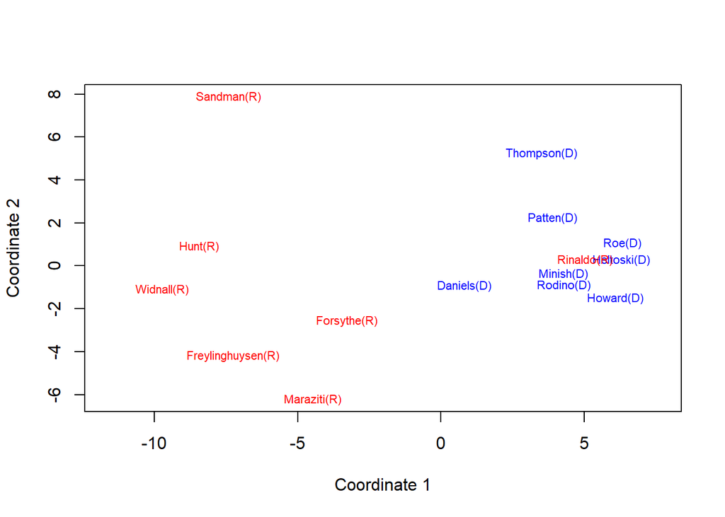

```r
demind <- grep("(D)",colnames(voting))
col <- rep("red",15)
col[demind] <- "blue"

plot(voting_mds$points[,1], voting_mds$points[,2],
     type = "n", xlab = "Coordinate 1", ylab = "Coordinate 2",
     xlim = range(voting_mds$points[,1])*1.2)
text(voting_mds$points[,1], voting_mds$points[,2],
     labels = colnames(voting), cex = 0.7, col = col)
```

**Use `ggrepel` fo better plots**

```r
library(ggplot2)
library(ggrepel)

voting.data <- data.frame(voting_mds$points)

set.seed(42)
ggplot(voting.data) +
  geom_point(aes(X1,X2), color = 'red') +
  geom_text_repel(aes(X1,X2,
                      label = rownames(voting.data))) +
  theme_classic(base_size = 16)
```

## 5.2 Use `ggrepel` fo better plots

[figure not shown]

## 5.3 Main message

Classical MDS:

- Finds low-dim projection that respects distances
- Optimal for euclidean distances
- No clear guarantees for other distances
- fast

Non-metric MDS:

- Squeezes data points on table
- respects only rankings of distances
- (locally) solves clear objective
- slow